# Assignment7

Wei Zheng

11/13/2019

## Speed Dating——非诚勿扰

案例背景：近年来相亲电视节目层出不穷，婚恋市场异常火爆。据统计婚恋交友市场在2016年收入近百亿收入。每个单身狗怎么才能获得异性的芳心？婚恋网站如何才能在最短的时间内帮助有婚恋需求的人找到自己心仪的对象？或许数据科学的思维可以帮我们找到这些问题的答案。

案例数据提供了芝加哥商学院相亲实验数据。该数据是芝加哥商学院Ray Fisman教授和Sheena Iyengar 教授2002年至2004年组织的相亲实验数据。实验的开始，组织者在该校网站上招募相亲者。志愿者需要在网站上注册，经审核后方可参与相亲活动。注册时需要留下个人信息，包括性别、年龄、种族、从事领域和兴趣。而由于数据集变量众多，请先查看assignment7文件夹中的Speed Dating Data Key.doc文件和[原始数据链接](https://www.kaggle.com/annavictoria/speed-dating-experiment)，了解数据变量。参考案例推文为[什么影响因素决定“非诚勿扰”](https://mp.weixin.qq.com/s/Pd9f_RWuAOY5rvUuVrE0Hg)。

这个案例的学习目标包括：

1. 了解数据的基本处理方法；
2. 学会对数据进行统计分析，并且适当解读。
3. 学会根据数据案例，应用决策树和随机森林的方法构建模型，并对模型结果进行解读

### 准备工作

清除工作环境，安装和加载一些需要的包。

```r
# 清除工作环境
cat("\014");rm(list=ls())
```

```r
####    设定字体为中文
# Sys.setlocale("LC_CTYPE","chs")
library(fmsb)  ##用于绘制雷达图
library(dplyr)  ##用于操作数据框，用于数据清洗和整理
library(ggplot2)  ##用于画图
library(gridExtra)  ##用于将多个ggplot2包的图形放入单个图形中
library(reshape2)  ##用于整合与重构数据集
library(rpart)  ##用于拟合决策树模型
library(rpart.plot)
library(pROC)  ##用于画ROC曲线
library(gplots)  ##用于画图
library(ROCR)  ##用于算AUC值
library(randomForest)  ##用于拟合随机森林模型
library(tidyr)  ##用于整理数据
```

### 任务一

找到数据data，读入样本数据，命名为raw.data;

```r
# 加载数据
raw.data <- read.csv('./Speed Dating Data.csv')
dat <- raw.data
```

### 任务二

统计参与此次调查的男性与女性的人数，并绘制条形图；根据数据集中的gender列，0代表女生，1代表男生，最后作图也以女生和男生为类别。

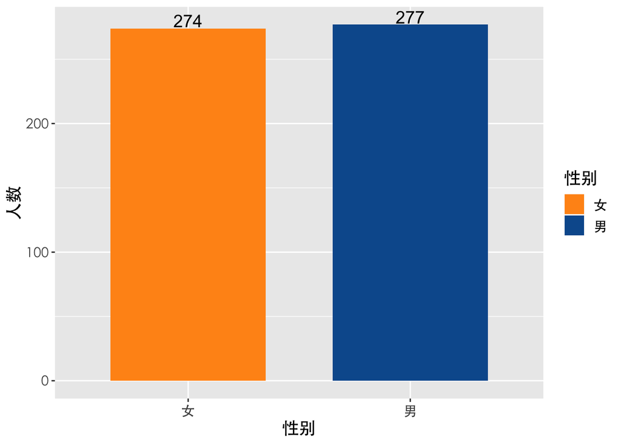

```r
# 画图设置
# 设置绘图颜色

mycolour_2<-scale_fill_manual(values=c("#FF9418","#085A9C"))
mycolour_22<-scale_fill_manual(values=c("#085A9C","#FF9418"))
mytheme1 <- theme(text=element_text(family="STHeiti",size=14))
mytheme2 <- theme(text=element_text(family="STHeiti",size=8))


mytheme <- mytheme1
par(family='STHeiti')


# 【性别】性别分布条形图

dat1 <- dat[c('iid','gender','race')] %>% unique()
dat6<-data.frame(table(dat1$gender))
colnames(dat6)<-c("性别","人数")
dat6$性别<-factor(dat6$性别,levels=c(0,1),labels=c("女","男")) # 转换为类别变量

p1<-ggplot(dat6,aes(x=性别,y=人数,fill=性别))+ ##aes参数说明对x和y进行图形映射，映射方式为fill
  geom_bar(stat="identity",width=0.7)+  #geom_bar指绘制条形图。stat = "identity"表示绘制原始数据，不进行统计变换
  geom_text(aes(label=dat6$人数),size=5,colour="black",vjust=-.1,hjust=0.5)+ #显示标签
  mycolour_2+mytheme
p1
```

### 任务三

统计参与此次调查的人群分性别、不同种族的人数，并绘制条形图；

为什么需要了解被调查人群的男女比例和种族分布呢？说说你的理解；数据集race代表种族，1-6分别代表：非裔，欧洲裔，拉丁裔，亚裔，北美土著，其他。

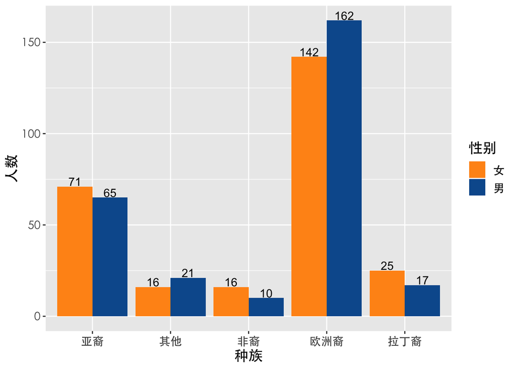

```r
# 【种族分性别分布】
dat1 <- dat[c('iid','gender','race')]
dat1<-unique(dat1)
colnames(dat1)<-c("编号","性别","种族")
dat1$性别<-factor(dat1$性别,levels=c(0,1),labels=c("女","男"))

dat1=dat1%>%mutate(种族=if_else(种族==1,"非裔",if_else(种族==2,"欧洲裔",if_else(种族==3,"拉丁裔",if_else(种族==4,"亚裔",if_else(种族==5,"北美土著",if_else(种族==6,"其他","未知")))))))

dat1<-data.frame(table(dat1$性别,dat1$种族))
colnames(dat1)<-c("性别","种族","人数")
dat1$种族=factor(dat1$种族,levels=dat1[which(dat1$性别=="女"),]$种族[order(dat1$人数,decreasing=TRUE)])
pp<-ggplot(dat1,aes(x=种族,y=人数,fill=性别))+
  geom_bar(stat="identity",position="dodge")+
  geom_text(aes(label=dat1$人数),size=4,colour="black",vjust=-.1,hjust=0.5,position=position_dodge(0.9))+
  mycolour_2+mytheme    #应用默认主题
pp
```

### 任务四

首先选择数据集中wave小于6或者wave大于9的数据，然后查看相亲者对不同兴趣的偏好程度并绘制成柱状图，观察图像，尝试解读柱状图呈现的现象。（图中均值指每个兴趣爱好各自分数的均值，每个兴趣的分数对应数据中sports列到yoga列共17个列，最后利用ggplot作图。）

提示：在相亲中最受欢迎的兴趣是什么？最不受欢迎的兴趣又是什么呢？

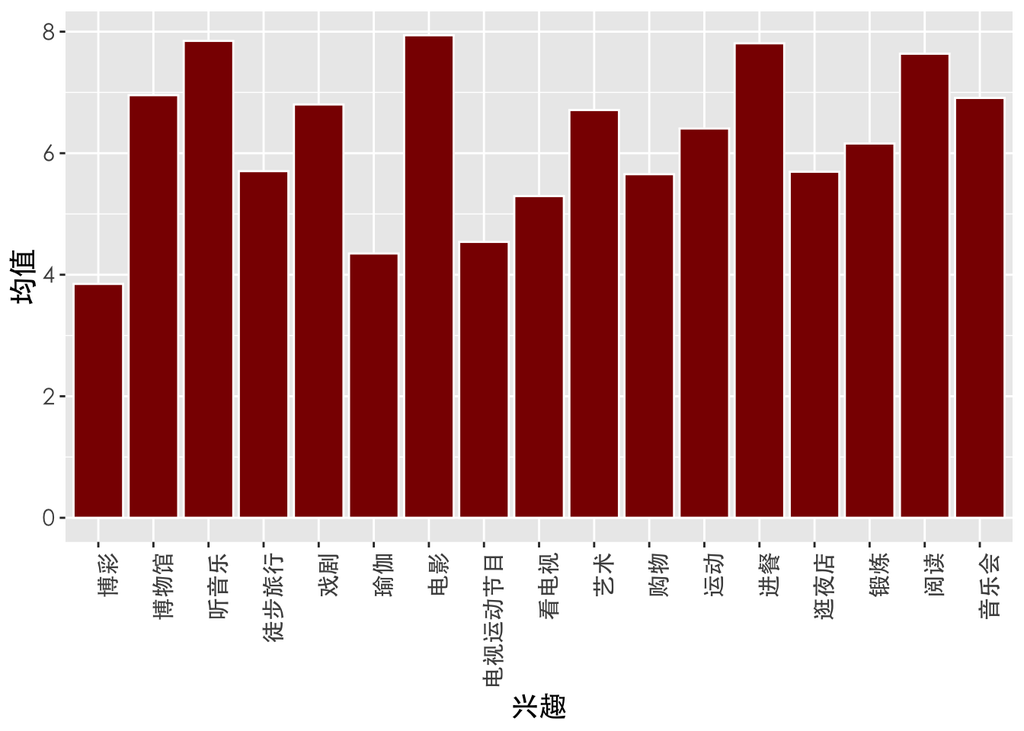

```r
# 数据准备
# 准备新数据框画图
sdd<-raw.data
# 选择符合条件的观测
sdd<-sdd %>%
  filter(wave>9 | wave <6)
# 移去income和tuition中的逗号","
# sdd = sdd %>%
#   mutate(income=as.numeric(gsub(",","",income))) %>%
#   mutate(tuition=as.numeric(gsub(",","",tuition)))
# 求各主观指标占总得分的比例
# sdd <- sdd %>%
#   mutate(sum1_1=attr1_1+sinc1_1+intel1_1+fun1_1+amb1_1+shar1_1) %>%
#   mutate(attr1_1n=attr1_1/(sum1_1/100)) %>%
#   mutate(sinc1_1n=sinc1_1/(sum1_1/100)) %>%
#   mutate(intel1_1n=intel1_1/(sum1_1/100)) %>%
#   mutate(amb1_1n=amb1_1/(sum1_1/100)) %>%
#   mutate(shar1_1n=shar1_1/(sum1_1/100))

# 【兴趣】
int <- sdd[, c("sports","tvsports","exercise","dining","museums","art","hiking","gaming","clubbing", "reading","tv","theater","movies","concerts","music","shopping", "yoga")]
f_mean <- function(x) {mean(x, na.rm=T)}
int_mean <- apply(int, 2, f_mean)
interest_cn <- c("运动","电视运动节目","锻炼","进餐","博物馆","艺术","徒步旅行","博彩","逛夜店", "阅读","看电视","戏剧","电影","音乐会", "听音乐","购物","瑜伽")
tmp <-  data.frame(interest_cn,int_mean)
names(tmp) <- c("interest","mean")
ggplot(tmp ) +
  geom_bar(aes(x=factor(interest),y=mean),stat="identity",colour=I("white") , fill=I("darkred"))  +
  theme(axis.text.x = element_text(angle = 90, hjust = 1)) + mytheme +
  labs(x="兴趣", y="均值")
```

### 任务五

用箱线图分别查看 是否进一步交往这一决策 和 相亲者在不同方面得分 （吸引力，真诚，智商，幽默，有抱负，共同爱好）的关系，观察这些箱线图，你可以得出哪些结论？利用ggplot，x选择dec列，y选择attr，sinc，intel，fun，amb，shar这些列分别作图。

提示：哪些方面会显著影响相亲者们进一步交往的意愿呢？

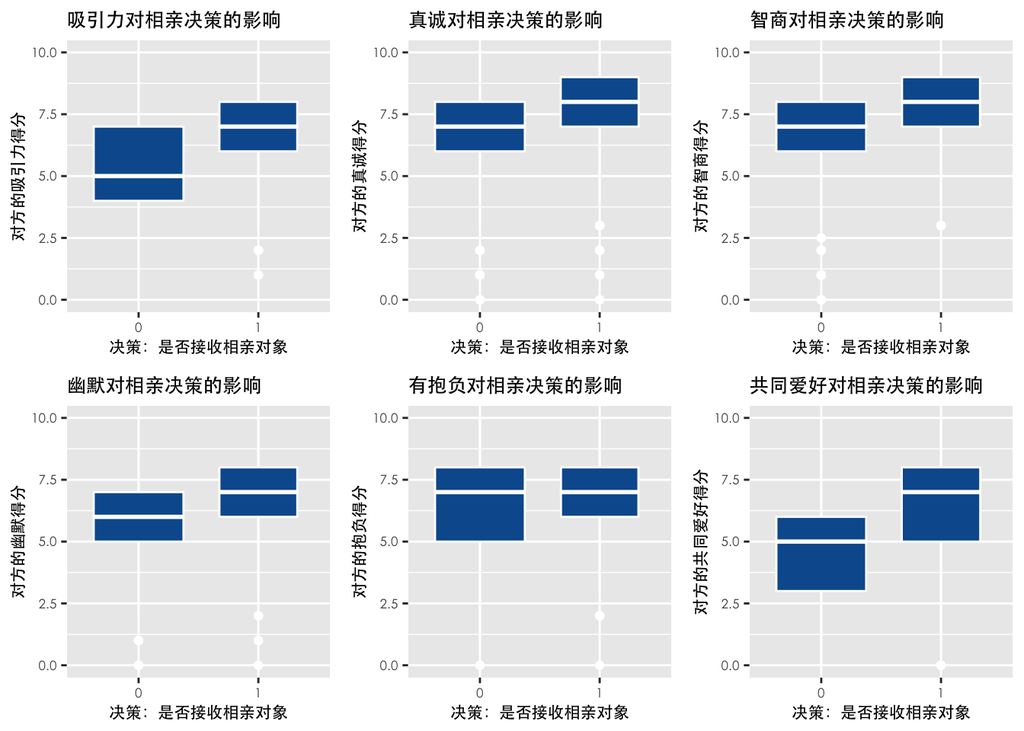

```r
# 【相亲者特点对相亲决策的影响】

mytheme <- mytheme2

# 箱线图设置
myboxplot <- geom_boxplot(position = position_dodge(width = 0.8), varwidth = TRUE, color = "white", fill = "#085A9C")


p1<-ggplot(dat, aes(x=as.factor(dec), y=attr)) +
  myboxplot +                    #应用默认直方图
  mytheme +                      #应用默认主题
  labs(x="决策：是否接收相亲对象", y="对方的吸引力得分", title="吸引力对相亲决策的影响")
p2<-ggplot(dat, aes(x=as.factor(dec), y=sinc)) +
  myboxplot +                    #应用默认直方图
  mytheme +                      #应用默认主题
  labs(x="决策：是否接收相亲对象", y="对方的真诚得分", title="真诚对相亲决策的影响")
p3<-ggplot(dat, aes(x=as.factor(dec), y=intel)) +
  myboxplot +                    #应用默认直方图
  mytheme +                      #应用默认主题
  labs(x="决策：是否接收相亲对象", y="对方的智商得分", title="智商对相亲决策的影响")
p4<-ggplot(dat, aes(x=as.factor(dec), y=fun)) +
  myboxplot +                    #应用默认直方图
  mytheme +                      #应用默认主题
  labs(x="决策：是否接收相亲对象", y="对方的幽默得分", title="幽默对相亲决策的影响")
p5<-ggplot(dat, aes(x=as.factor(dec), y=amb)) +
  myboxplot +                    #应用默认直方图
  mytheme +                      #应用默认主题
  labs(x="决策：是否接收相亲对象", y="对方的抱负得分", title="有抱负对相亲决策的影响")
p6<-ggplot(dat, aes(x=as.factor(dec), y=shar)) +
  myboxplot +                    #应用默认直方图
  mytheme +                      #应用默认主题
  labs(x="决策：是否接收相亲对象", y="对方的共同爱好得分", title="共同爱好对相亲决策的影响")
grid.arrange(p1,p2,p3,p4,p5,p6,ncol=3,nrow=2)
```

### 任务六

经过之前的任务，你已经对相亲成功的影响因素有了一些基本的了解。现在，尝试用分类决策树的方法来分析相亲中主观指标上的得分对相亲结果的影响吧。

同样的，先准备建模分析需要的数据框；将女性和男性分别存储到名为female和male的数据框中，并用summary进行展示。

提示：主观指标为“吸引力”,“真诚”,“智力”,“幽默”,“雄心”,“共同爱好”。同时，考虑性别差异的存在，需要对男性和女性分开建模。

```r
# 准备数据框
vars1 <- c('dec','gender','attr','sinc','intel','fun','amb','shar')
df.4.1 <- dat[vars1]
names(df.4.1) <- c("决定","性别","吸引力","真诚","智力","幽默","雄心","共同爱好")

# 转换数据类型
df.4.1$决定 <- factor(df.4.1$决定, levels = c(0,1), labels = c("拒绝","接收"))
df.4.1$性别 <- factor(df.4.1$性别, levels = c(0,1), labels = c("女","男"))

female <- df.4.1[df.4.1$性别=="女",][-2]
male <- df.4.1[df.4.1$性别=="男",][-2]

print("Summary of Female")
```

```
## [1] "Summary of Female"
```

```r
summary(female)
```

```
##    决定          吸引力            真诚           智力
##  拒绝:2655   Min.   : 0.000   Min.   : 0.0   Min.   : 0.000
##  接收:1529   1st Qu.: 5.000   1st Qu.: 6.0   1st Qu.: 7.000
##              Median : 6.000   Median : 7.0   Median : 8.000
##              Mean   : 5.919   Mean   : 7.1   Mean   : 7.447
##              3rd Qu.: 7.000   3rd Qu.: 8.0   3rd Qu.: 8.000
##              Max.   :10.000   Max.   :10.0   Max.   :10.000
##              NA's   :101      NA's   :130    NA's   :147
##       幽默             雄心           共同爱好
##  Min.   : 0.000   Min.   : 0.000   Min.   : 0.000
##  1st Qu.: 5.000   1st Qu.: 6.000   1st Qu.: 4.000
##  Median : 6.000   Median : 7.000   Median : 6.000
##  Mean   : 6.281   Mean   : 6.953   Mean   : 5.407
##  3rd Qu.: 8.000   3rd Qu.: 8.000   3rd Qu.: 7.000
##  Max.   :10.000   Max.   :10.000   Max.   :10.000
##  NA's   :183      NA's   :362      NA's   :576
```

```r
print("Summary of Male")
```

```
## [1] "Summary of Male"
```

```r
summary(male)
```

```
##    决定          吸引力           真诚             智力
##  拒绝:2205   Min.   : 0.00   Min.   : 0.000   Min.   : 0.00
##  接收:1989   1st Qu.: 5.00   1st Qu.: 6.000   1st Qu.: 6.00
##              Median : 7.00   Median : 7.000   Median : 7.00
##              Mean   : 6.46   Mean   : 7.251   Mean   : 7.29
##              3rd Qu.: 8.00   3rd Qu.: 8.000   3rd Qu.: 8.00
##              Max.   :10.00   Max.   :10.000   Max.   :10.00
##              NA's   :101     NA's   :147      NA's   :149
##       幽默            雄心           共同爱好
##  Min.   : 0.00   Min.   : 0.000   Min.   : 0.00
##  1st Qu.: 5.00   1st Qu.: 5.000   1st Qu.: 4.00
##  Median : 7.00   Median : 7.000   Median : 6.00
##  Mean   : 6.52   Mean   : 6.603   Mean   : 5.54
##  3rd Qu.: 8.00   3rd Qu.: 8.000   3rd Qu.: 7.00
##  Max.   :10.00   Max.   :10.000   Max.   :10.00
##  NA's   :167     NA's   :350      NA's   :491
```

### 任务七

利用rpart函数(参数method选择为’class’)对女性和男性（即female和male的数据集）分别建立决策树模型，并绘制得到的决策树；

仔细对比，尝试解读模型结果和得到的结论；

提示：可以用par(mfrow=c(1,2))将图像并列放置。

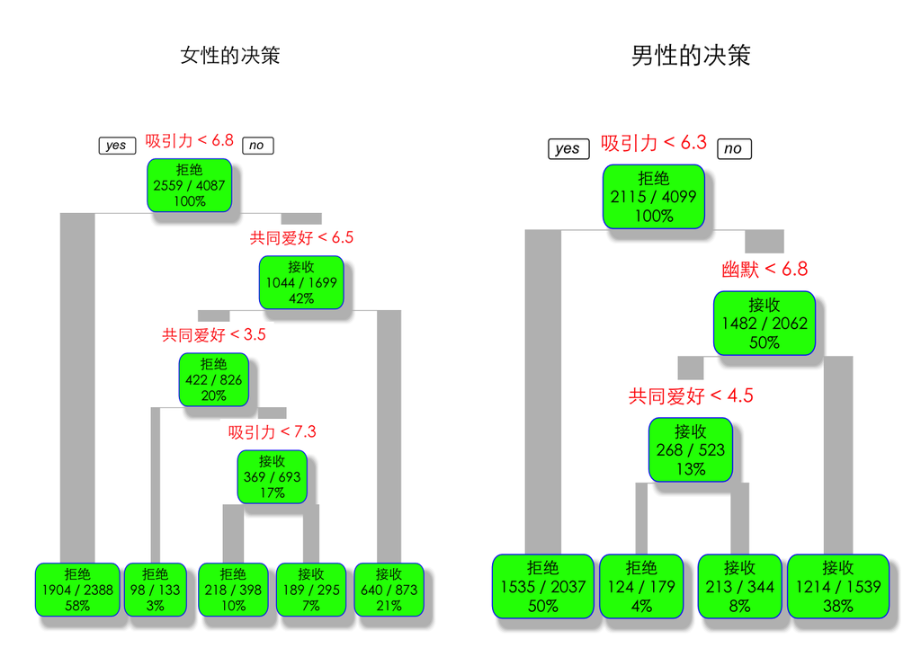

```r
# 决策树模型
par(mfrow=c(1,2), family='STXihei')
# 对女性决策建模，模型拟合
fit.f <- rpart(决定~., method ='class',data = female)

# 绘制决策树
rpart.plot(fit.f, branch=1, branch.type=2, type=1, extra=102,
shadow.col='gray', box.col='green',
border.col='blue', split.col='red',
split.cex=1.2, main='女性的决策')

# 对男性决策建模，模型拟合
fit.m <- rpart(决定~., method ='class',data = male)

# 绘制决策树
rpart.plot(fit.m, branch=1, branch.type=2, type=1, extra=102,
shadow.col='gray', box.col='green',
border.col='blue', split.col='red',
split.cex=1.2, main='男性的决策')
```

事实上，我们还可以使用rattle包提供的方法，绘制出更美观的决策树（如下图），有兴趣的同学不妨自己尝试一下吧！

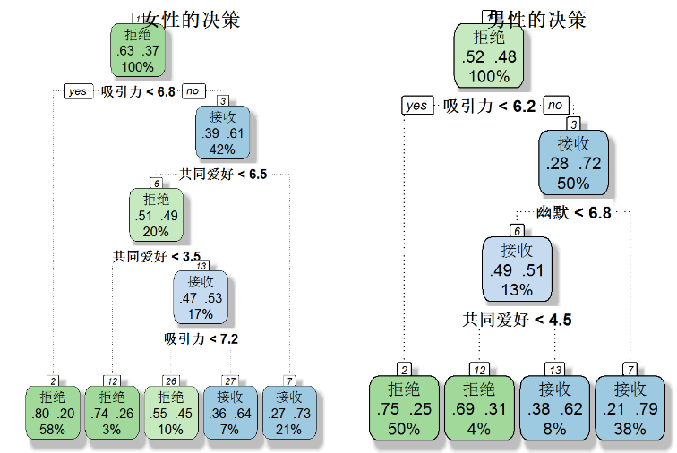